# **Checking for appropriate priors**

Jackson Zhou

Our task is to choose the distributions of $\tilde{\theta}_1$ and $\tilde{\theta}_2$ such that:
$$\alpha=\left(\frac{e^{\tilde{\theta}_1}}{e^{\tilde{\theta}_1}+1}\right)\left(\frac{e^{\tilde{\theta}_2}}{e^{\tilde{\theta}_2}+1}\right),\ \beta=\left(\frac{e^{\tilde{\theta}_1}}{e^{\tilde{\theta}_1}+1}\right)\left(\frac{1}{e^{\tilde{\theta}_2}+1}\right)$$

are distributed reasonably close to $\text{Beta}(1.5,10)$ and $\text{Beta}(10,1.5)$ respectively. To help us out, we first visualise samples from these Beta distributions using a histogram:

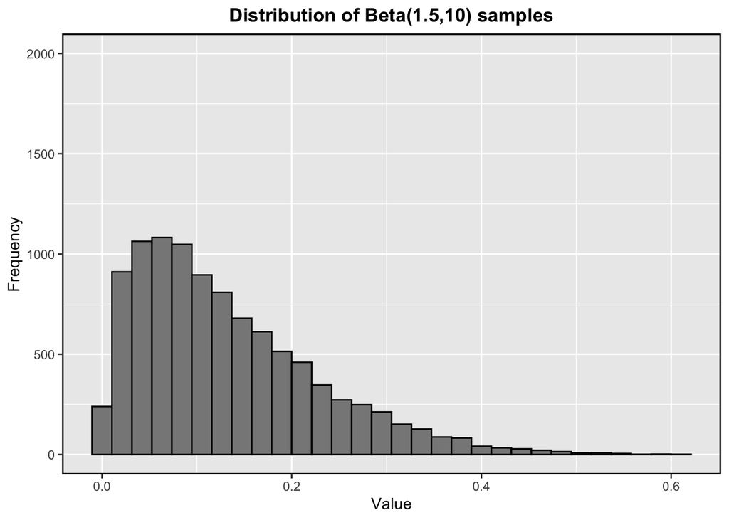

```r
set.seed(3830)
ideal.alpha.sample <- rbeta(n = 10000, shape1 = 1.5, shape2 = 10)
ideal.beta.sample <- rbeta(n = 10000, shape1 = 10, shape2 = 1.5)

ideal.alpha.plot <- ideal.alpha.sample %>%
  data.frame() %>%
  ggplot(mapping = aes(x = .)) +
  geom_histogram(bins = 30, colour = "black", fill = "#888888") +
  labs(title = "Distribution of Beta(1.5,10) samples",
       x = "Value",
       y = "Frequency") +
  ylim(c(0, 2000)) +
  theme(plot.title = element_text(face = "bold", hjust = 0.5),
        panel.border = element_rect(colour = "black", fill = NA, size = 1))
ideal.alpha.plot
```

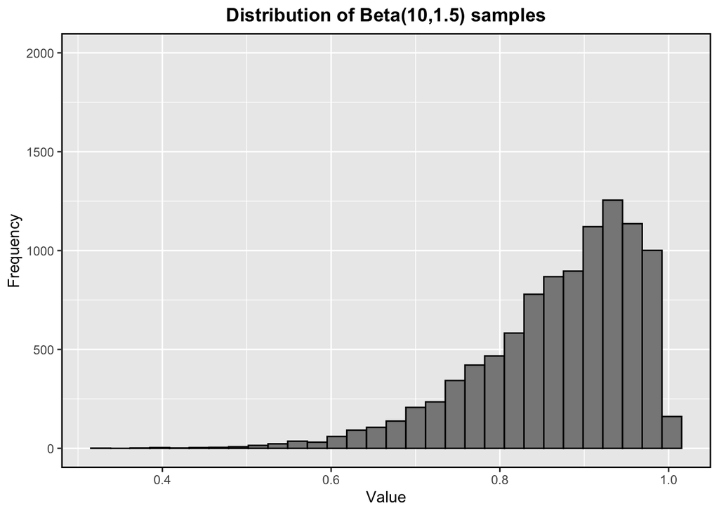

```r
ideal.beta.plot <- ideal.beta.sample %>%
  data.frame() %>%
  ggplot(mapping = aes(x = .)) +
  geom_histogram(bins = 30, colour = "black", fill = "#888888") +
  labs(title = "Distribution of Beta(10,1.5) samples",
       x = "Value",
       y = "Frequency") +
  ylim(c(0, 2000)) +
  theme(plot.title = element_text(face = "bold", hjust = 0.5),
        panel.border = element_rect(colour = "black", fill = NA, size = 1))
ideal.beta.plot
```

I will now generate appropriate samples of $\tilde{\theta}_1$ and $\tilde{\theta}_2$ (with their distributions chosen via guess-and-check), and visualise the corresponding distributions of:

$$A=\frac{e^{\tilde{\theta}_1}}{e^{\tilde{\theta}_1}+1},\ B=\frac{e^{\tilde{\theta}_2}}{e^{\tilde{\theta}_2}+1},\ C=\frac{1}{e^{\tilde{\theta}_2}+1},\ \alpha=A\cdot B\ \text{ and }\ \beta=A\cdot C$$

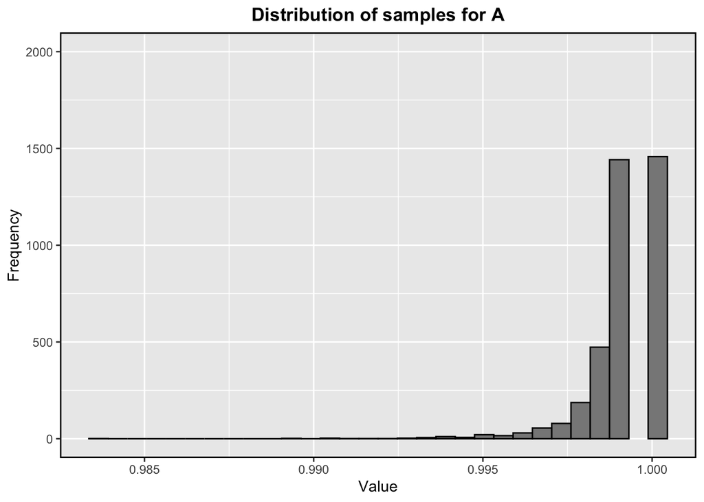

```r
set.seed(3830)
theta.1.tilde.sample <- rnorm(n = 10000, mean = 8, sd = 1)
theta.2.tilde.sample <- rnorm(n = 10000, mean = -2, sd = 1)
A.sample <- exp(theta.1.tilde.sample)/(exp(theta.1.tilde.sample) + 1)
B.sample <- exp(theta.2.tilde.sample)/(exp(theta.2.tilde.sample) + 1)
C.sample <- 1/(exp(theta.2.tilde.sample) + 1)
alpha.sample <- A.sample*B.sample
beta.sample <- A.sample*C.sample

A.plot <- A.sample %>%
  data.frame() %>%
  ggplot(mapping = aes(x = .)) +
  geom_histogram(bins = 30, colour = "black", fill = "#888888") +
  labs(title = "Distribution of samples for A",
       x = "Value",
       y = "Frequency") +
  ylim(c(0, 2000)) +
  theme(plot.title = element_text(face = "bold", hjust = 0.5),
        panel.border = element_rect(colour = "black", fill = NA, size = 1))
A.plot
```

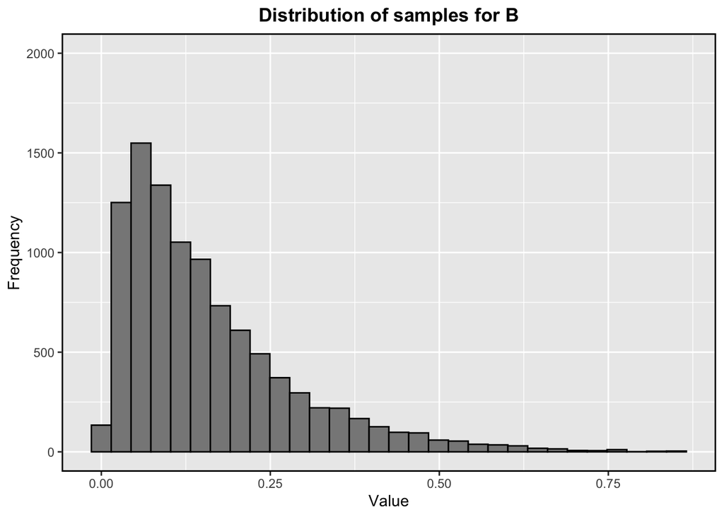

```r
B.plot <- B.sample %>%
  data.frame() %>%
  ggplot(mapping = aes(x = .)) +
  geom_histogram(bins = 30, colour = "black", fill = "#888888") +
  labs(title = "Distribution of samples for B",
       x = "Value",
       y = "Frequency") +
  ylim(c(0, 2000)) +
  theme(plot.title = element_text(face = "bold", hjust = 0.5),
        panel.border = element_rect(colour = "black", fill = NA, size = 1))
B.plot
```

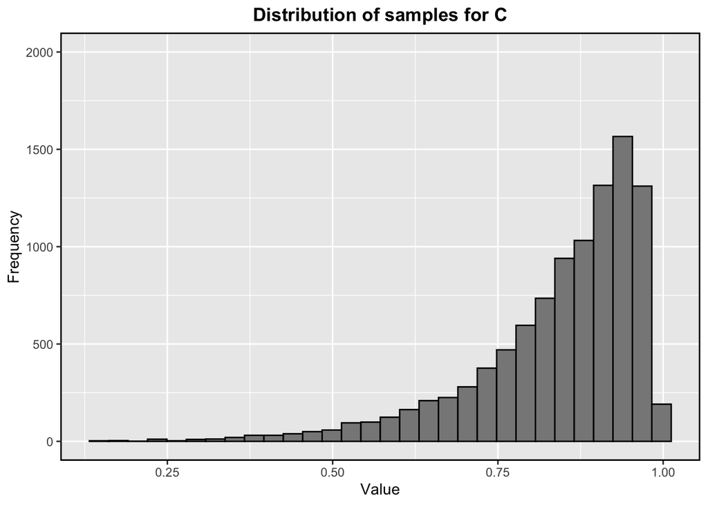

```r
C.plot <- C.sample %>%
  data.frame() %>%
  ggplot(mapping = aes(x = .)) +
  geom_histogram(bins = 30, colour = "black", fill = "#888888") +
  labs(title = "Distribution of samples for C",
       x = "Value",
       y = "Frequency") +
  ylim(c(0, 2000)) +
  theme(plot.title = element_text(face = "bold", hjust = 0.5),
        panel.border = element_rect(colour = "black", fill = NA, size = 1))
C.plot
```

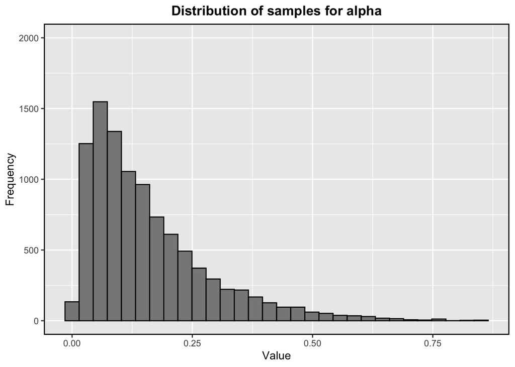

```r
alpha.plot <- alpha.sample %>%
  data.frame() %>%
  ggplot(mapping = aes(x = .)) +
  geom_histogram(bins = 30, colour = "black", fill = "#888888") +
  labs(title = "Distribution of samples for alpha",
       x = "Value",
       y = "Frequency") +
  ylim(c(0, 2000)) +
  theme(plot.title = element_text(face = "bold", hjust = 0.5),
        panel.border = element_rect(colour = "black", fill = NA, size = 1))
alpha.plot
```

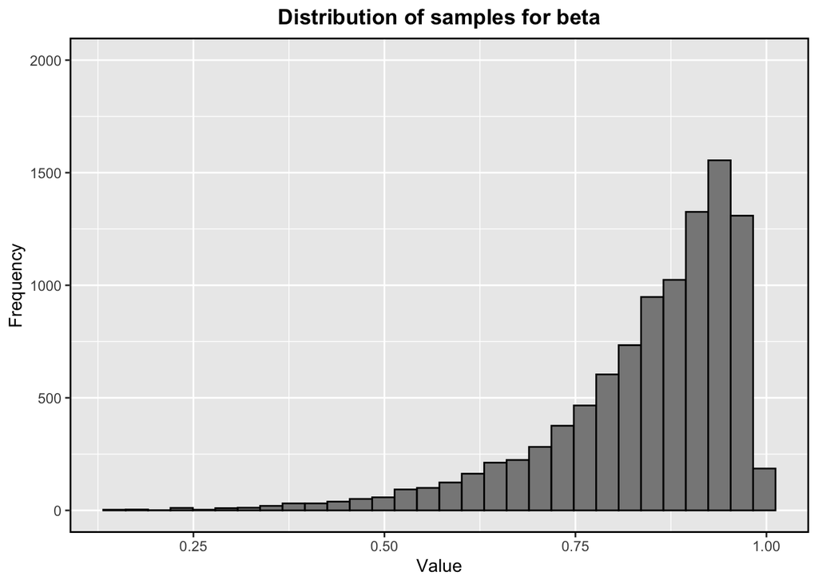

```r
beta.plot <- beta.sample %>%
  data.frame() %>%
  ggplot(mapping = aes(x = .)) +
  geom_histogram(bins = 30, colour = "black", fill = "#888888") +
  labs(title = "Distribution of samples for beta",
       x = "Value",
       y = "Frequency") +
  ylim(c(0, 2000)) +
  theme(plot.title = element_text(face = "bold", hjust = 0.5),
        panel.border = element_rect(colour = "black", fill = NA, size = 1))
beta.plot
```

We see that by choosing the priors of $\tilde{\theta}_1$ and $\tilde{\theta}_2$ to be $\mathcal{N}(8,1)$ and $\mathcal{N}(-2,1)$ respectively, the corresponding distributions of $\alpha$ and $\beta$ are reasonably close to the suggested priors. Checking that our samples of $\alpha$ and $\beta$ never sum to more than 1:

```r
sum((alpha.sample + beta.sample) > 1)
```

```
## [1] 0
```

We see that none of the 10000 samples of $\alpha$ and $\beta$ generated using this method summed to more than 1, which is what we want. Making some grid plots for easier comparison:

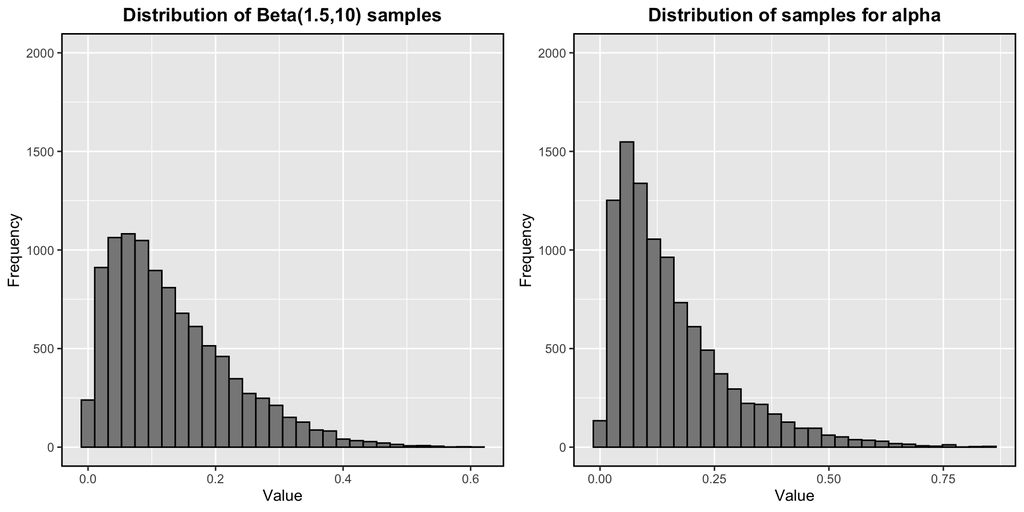

```r
plot_grid(ideal.alpha.plot, alpha.plot, nrow = 1)
```

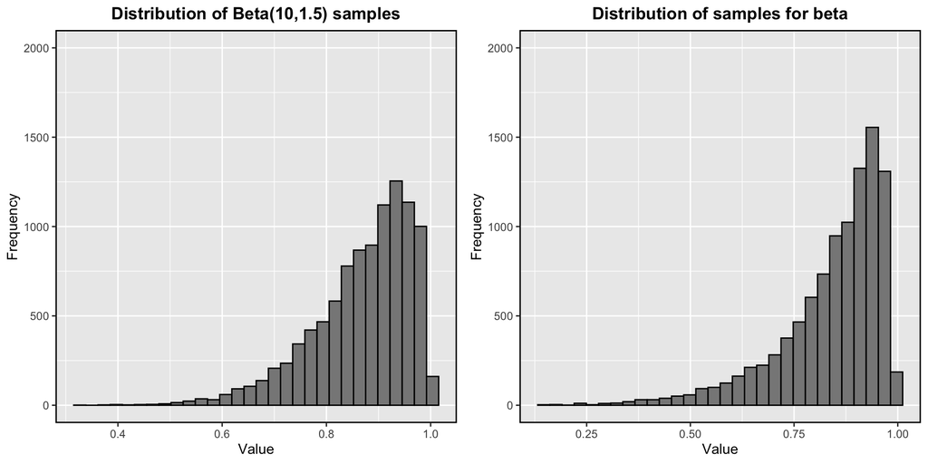

```r
plot_grid(ideal.beta.plot, beta.plot, nrow = 1)
```